# Koolitöötajate liikumisaktiivsus

Kerli Mooses

02/05/2020

### Sissejuhatus

Ebapiisav liikumisaktiivsus on suureks terviseriskiks nii täiskasvanutele kui ka lastele ([WHO](https://www.who.int/dietphysicalactivity/pa/en/)). Tervise säilitamise seisukohalt peaksid täiskasvanud nädala jooksul liikuma iga päev vähemalt 30 minutit mõõduka intensiivsusega, nii et tekiks soojatunne ja hingamine kiireneks ([terviseinfo.ee](https://www.terviseinfo.ee/et/valdkonnad/liikumine/kuidas-eesti-inimesed-liiguvad)). Tervise tugevdamiseks peaks aga koguma vähemalt 300 minutit mõõdukat liikumisaktiivsust või 150 minutit tugevat liikumisaktiivsust nädalas ([WHO](https://www.who.int/dietphysicalactivity/pa/en/)). Samas küsitlusuuringute kohaselt on vaid 11% Eesti täiskasvanutest on 4-6 korda nädalas kehaliselt aktiivsed ([terviseinfo.ee](https://www.terviseinfo.ee/et/valdkonnad/liikumine/kuidas-eesti-inimesed-liiguvad)). Eestis on vähe uuringuid, kus oleks täiskasvanute liikumisaktiivsust mõõdetud objektiivselt liikumisanduritega, mis võimaldaks paremini hinnata tegelikult kogutud aktiivsusminuteid. Antud töös eesmärk on kirjeldada Eesti koolitöötajate objektiivselt mõõdetud liikumisaktiivsust.

### Metoodika

Uuringu käigus mõõdeti 2019. aasta sügisel 44 kooli töötajate liikumisaktiivsust üle Eesti. Kõik osalejad (n = 1190) kandsid liikumisandurit vööl vähemalt nädal aega ning eemaldasid selle ainult veega seotud tegevusteks ja ööuneks. Lisaks liikumisanduri kandmisele täitsid uuringus osalenud liikumisanduri päevikut ja lühikese küsimustiku liikumisharjumuste ja liikumisega seotud hoiakute kohta. Peale andmete puhastamist jäi analüüsi 1119 koolitöötajat, kellel oli vähemalt kolmel mõõtmispäeval vähemalt kaheksa kandmistunni andmed. Analüüsi jaoks arvutati iga osaleja mõõtmispäevade keskmine liikumisaktiivsus. Vastavalt küsimustikus märgitud ametile moodustati järgmised ametirühmad:

- Aineõpetajad - õpetajad, kes olid ennast märkinud ainule aineõpetajaks
- Klassiõpetajad - õpetajad, kes olid ennast märkinud ainult klassiõpetajaks
- Aine- ja klassiõpetajad - õpetajad, kes olid ennast märkinud nii aine kui ka klassiõpetajaks
- Juhtkond - direktor, direktori asetäitjad, õppealajuhataja, personali-, IT-, arendus-, haldusjuht jt juhid
- Kantselei - sekretär, raamatukoguhoidja, juhiabi, kantseleitöötaja.
- Tugipersonal - eripedagoog, sotsiaalpedagoog, psühholoog, logopeed, noorsootöötaja, haridustehnoloog jms.
- Abitöötaja - köögitööline, aednik, remontija, valvelaua- ja garderoobitöötajat jms.

Kasutades Evensoni lõikepunkte teisendati liikumisanduri andmed klmeks liikumisintensiivsuseks:

- mõõdukas ja tugev liikumisaktiivsus (*moderate to vigorous physical activity*, MVPA) ehk liikumine kui südametöö kiireneb oluliselt, tekib soojatunne, higistamine.
- kerge liikumisaktiivsus (*light physical activity*) ehk kerge liikumine nagu näiteks jalutamine, kerge rattasõit.
- kehaliselt mitteaktiivne aeg (*sedentary time*) ehk aeg veedetud istudes, lamades, seistes.

### Tulemused

Kõige enam osales uuringus õpetajaid ning kõige vähem oli kantseleitöötajaid (joonis 1).

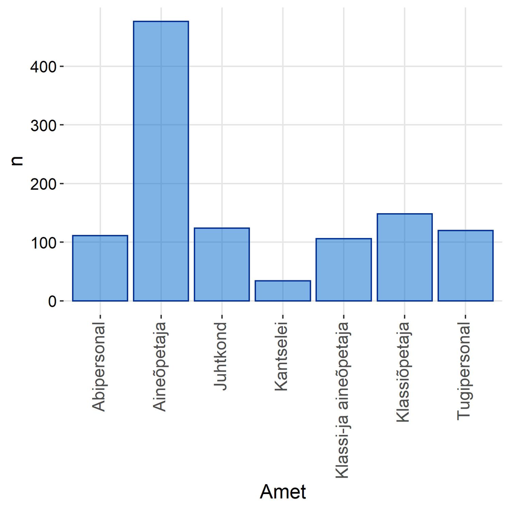

**Joonis 1.** Uuringus osalenute jaotus ametikohtade lõikes (N = 1119).

Uuringus osales 44 kooli, kelle töötajate keskmine mõõduka ja tugeva liikumisaktiivsuse (MVPA) jaotus on esitatud joonisel 2. Uuringus osalenud koolide mõõtmispäevade keskmine MVPA jäi vahemikku 37-67 minutit.

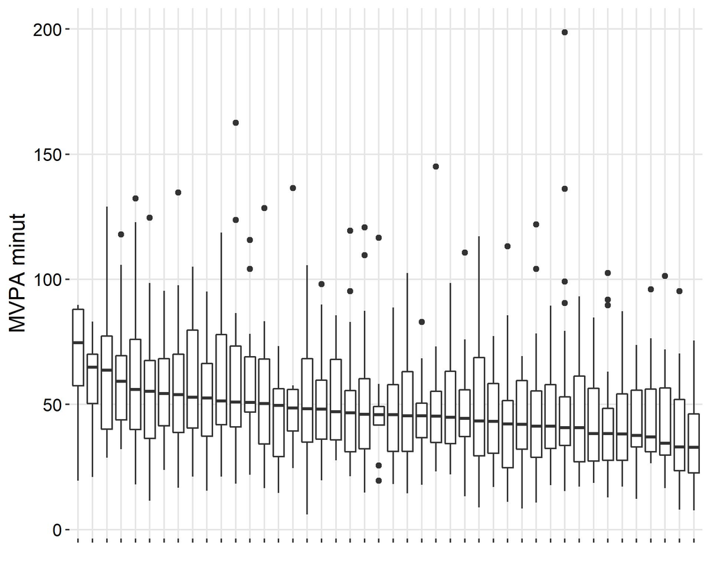

**Joonis 2.** Mõõduka ja tugeva liikumisaktiivsuse (MVPA) jaotus kooliti (N = 1119)

Kõik vaadeldud ametid olid liikumisaktiivsuse osas sarnased - nädalane keskmine MVPA jäi ametite lõikes vahemikku 45-52 minutit. Samuti olid ametirühmad sarnased erineva intensiivsusega liikumisaktiivsuse osakaalu poolest (joonis 3). Vaid abipersonali puhul on märgata mõningast suuremat osakaalu kerges liikumisaktiivsuses.

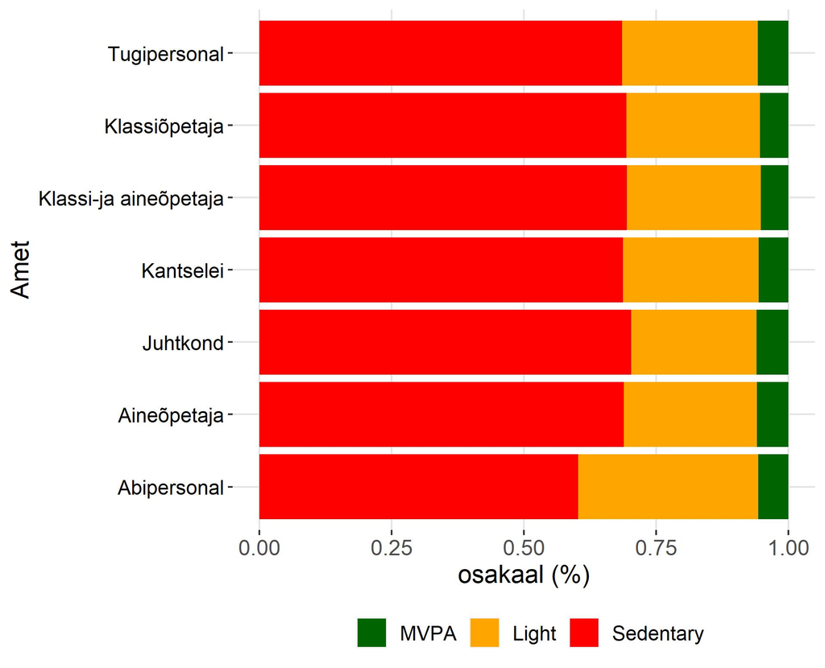

**Joonis 3.** Erineva intensiivsusega liikumisaktiivsuse osakaal ametirühmade kaupa (N = 1119). *MVPA - mõõdukas ja tugev liikumisaktiivsus, Light - kerge liikumisaktiivsus, Sedentary - kehaliselt mitteaktiivne aeg.*

Minimaalselt peaksid täiskasvanud koguma iga päev vähemalt 30 minutit MVPA-d. Järgnevalt on vaadatud kuidas jaotuvad eri ametis koolitöötajad selle alusel, mitmel mõõtmispäeval nad kogusid vähemalt 30 minutit MVPAd ehk saavutasid minimaalse liikumisaktiivsuse taseme (joonis 4). Kui enamustes ametirühmade jäi nende töötajate osakaal, kes mitte ühelgi päeval ei kogunud 30 minutit MVPAd vahemikku 2.8-5.0%, siis 16% abipersonalist ei kogunud mitte ühelgi mõõtmispäeval 30 minutit MVPA-d. Vähemalt kolmveerandil mõõtmispäevadest saavutas minimaalse liikumisaktiivsuse taseme 50% juhtkonna esinajatest. Kõige väiksem osakaal töötajaid, kes saavutas vähemalt 75% päevadest vähemalt 30 minutit MVPA-d oli tugipersonali ja klassi-ja aineõpetajate seas (mõlemas 40%). Selliste töötajate osakaal, kes igal mõõtmispäeval kogusid vähemalt 30 minutit MVPA-d oli kõige enam abitöötajate ja klassiõpetajate seas (mõlemas 27%) ning kõige vähem kantselei töötajate seas (20%).

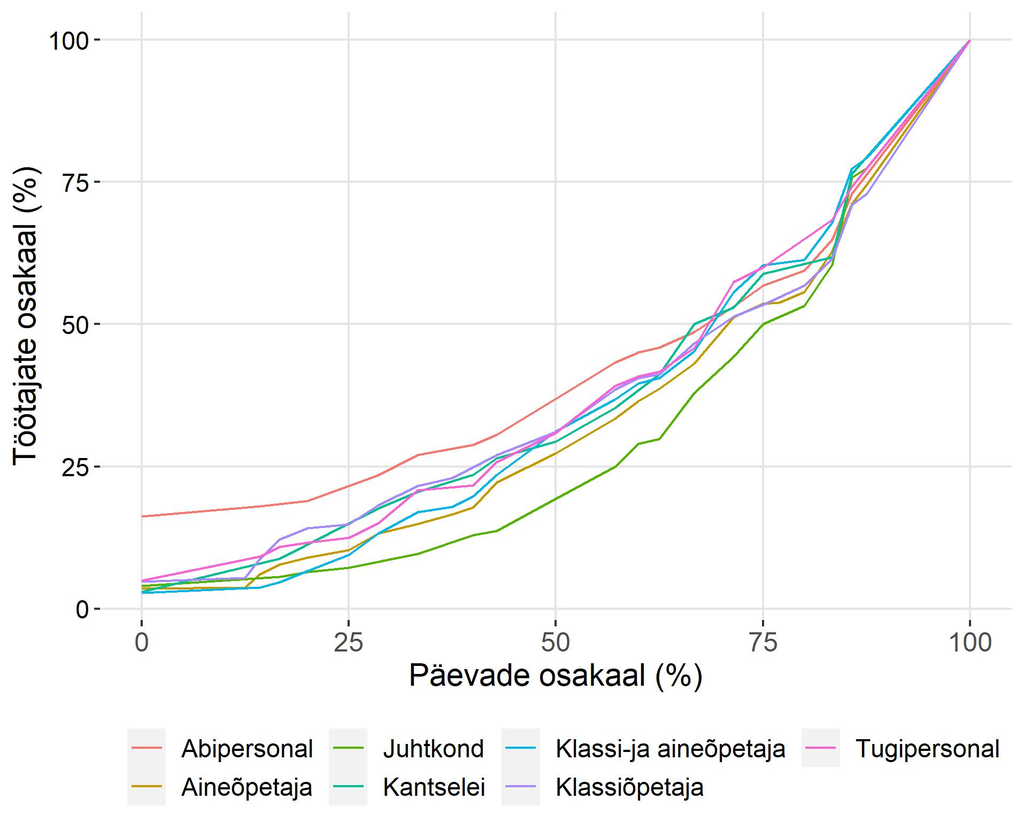

**Joonis 4.** Mõõtmispäevade ja töötajate osakaalu kumulatiivne jaotus, kui uuritav kogus vähemalt 30 minutit MVPA-d ametirühmade lõikes (N = 1119)

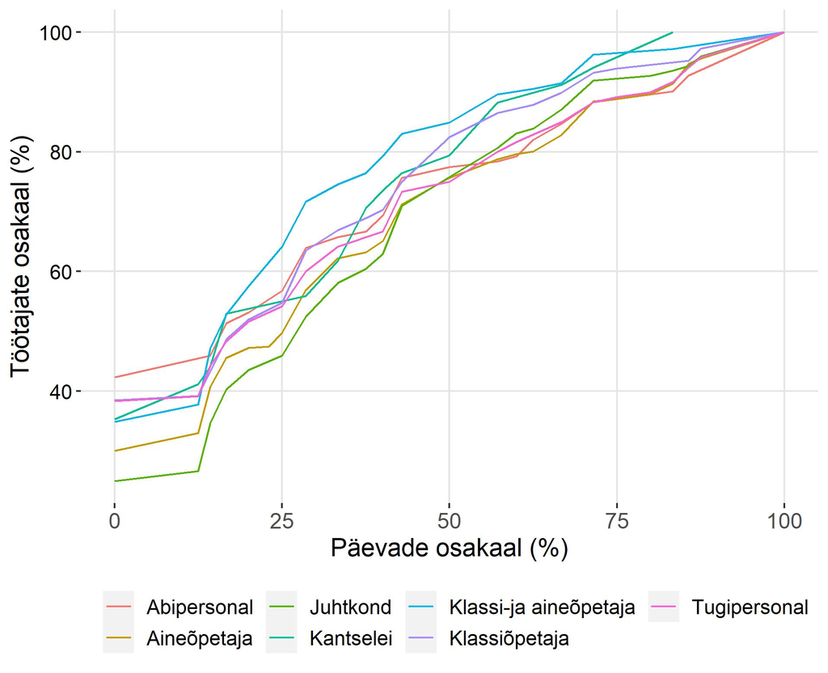

**Joonis 5.** Mõõtmispäevade ja töötajate osakaalu kumulatiivne jaotus, kui uuritav kogus vähemalt 60 minutit MVPA-d ametirühmade lõikes (N = 1119)

Üldiselt on teada, et vanuse kasvades liikumisaktiivsus väheneb. Samas vaadates kõiki koolitöötajaid, siis nende seas antud seaduspära ei pea paika (r = -0.06, p = 0.062) (joonis 6). Vähest statistiliselt olulist langust nädala keskmises MVPA-s vanuse kasvades esines ainult abipersonali seas (r = -0.213, p = 0.026)

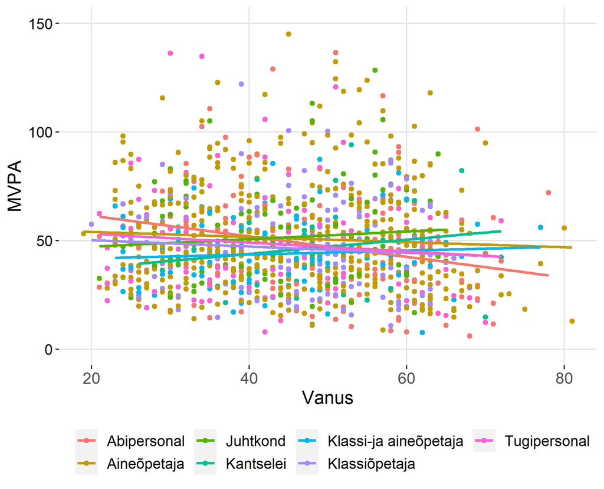

**Joonis 6.** Vanuse ja mõõduka ja tugeva intensiivsusega liikumisaktiivsuse (MVPA) seos ametirühmade lõikes (N = 1119)